# FIS project : main notebook

### 1) Cargamos los datos

Para empezar, se carga el train set y el test set.

```r
df_train <-read.csv2("data/train.csv")
df_test <- read.csv2("data/test.csv")
```

Se verifican las dimensiones del dataset de entrenamiento y del dataset de test.

```r
dim_train = dim(df_train)
print(paste("El cunjunto de entrenamiento tiene ", dim_train[1],"valores y ", dim_train[2], "variables." ))
```

```
[1] "El cunjunto de entrenamiento tiene  45211 valores y  17 variables."
```

```r
dim_test = dim(df_test)
print(paste("El cunjunto de test tiene ", dim_test[1],"valores y ", dim_test[2], "variables." ))
```

```
[1] "El cunjunto de test tiene  4521 valores y  17 variables."
```

Se visualiza el header del dataset de entrenamiento para ver un poco los datos.

```r
head(df_train)
```

|  | age | job | marital | education | default | balance | housing | loan | contact | day | month | duration | campaign | pdays | previous | poutcome | y |
| --- | --- | --- | --- | --- | --- | --- | --- | --- | --- | --- | --- | --- | --- | --- | --- | --- | --- |
| 1 | 58 | management | married | tertiary | no | 2143 | yes | no | unknown | 5 | may | 261 | 1 | -1 | 0 | unknown | no |
| 2 | 44 | technician | single | secondary | no | 29 | yes | no | unknown | 5 | may | 151 | 1 | -1 | 0 | unknown | no |
| 3 | 33 | entrepreneur | married | secondary | no | 2 | yes | yes | unknown | 5 | may | 76 | 1 | -1 | 0 | unknown | no |
| 4 | 47 | blue-collar | married | unknown | no | 1506 | yes | no | unknown | 5 | may | 92 | 1 | -1 | 0 | unknown | no |
| 5 | 33 | unknown | single | unknown | no | 1 | no | no | unknown | 5 | may | 198 | 1 | -1 | 0 | unknown | no |
| 6 | 35 | management | married | tertiary | no | 231 | yes | no | unknown | 5 | may | 139 | 1 | -1 | 0 | unknown | no |

### 2) Exploración y visualización de los datos

Para conocer un poco más los datos se procede a visualizar las variables del dataset de entrenamiento.

```r
# Se carga la librería tidyverse para manipular los datos más facilmente

library(tidyverse)
# Gracias a eso, ahora se puede utilizar el operador %>% para crear una pipeline en la que se apliquen varias operaciones a los datos (por ejemplo "mutate" para añadir nuevas variables, "select" para guardar solamente las variables que queremos, "filter" para filtrar los datos según valores, etc).
```

#### 2.1) Visualización de la variable “age”

Esta variable representa la edad de cada cliente. Es una variable numérica y se va a visualizar con un gráfico que representa en el eje “x” la edad y en el eje “y” el número de clientes que tienen esa edad. Sin embargo, como hay muchos edades diferentes se van a crear grupos de edad para que sea más facil visualizar.

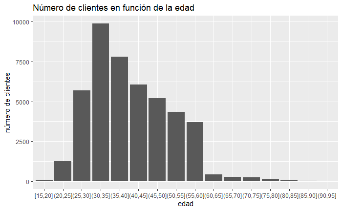

```r
# se crean grupos de edad porque hay muchos edades diferentes
# se crea una variable que cuenta para cada grupo de edad el número de clientes

edad <- df_train %>%
  mutate(edad_interval = cut_interval(df_train$age, length = 5)) %>%
  group_by(edad_interval) %>%
  count()

# se visualiza eso en un gráfico

 ggplot(edad, aes(x = edad_interval, y=n)) +
   geom_bar(stat="identity") +
   ggtitle("Número de clientes en función de la edad") +
   labs(x="edad", y = "número de clientes")
```

Se puede ver que la mayoria de los clientes tienen entre 25 y 60 años y muchos tienen entre 30 y 40 años. Los clientes representan bien la mayoria de la población trabajadora.

#### 2.2) Visualización de la variable “job”

Esta variable representa qué tipo de trabajo tiene cada cliente. Es una variable categórica (es decir que la variable sólo puede tomar un número finito de categorías) y nominal (es decir que no hay orden entre las diferentes categorías). Se va a visualizar con un gráfico circular.

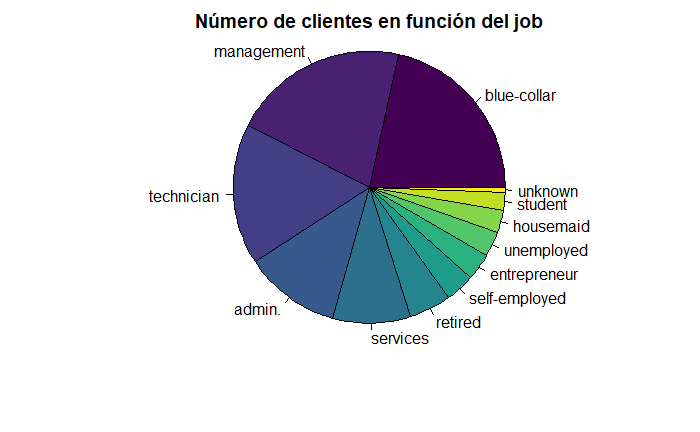

```r
# se crea una variable que cuenta para cada job el número de clientes, y se clasifican los jobs del que tiene más clientes al que tiene menos

job <- df_train %>%
  group_by(df_train$job) %>%
  count() %>%
  arrange(desc(n))

# se va a utilizar la paleta de colores "viridis" para la visualización (hace falta descomentar la siguiente línea si ya no está instalado)
# install.packages("viridis")
library("viridis")
# se construye el gráfico
pie(x=job$n,
    labels = job$`df_train$job`,
    radius = 1,
    main = "Número de clientes en función del job",
    col = viridis(length(job$n)))
```

Ahora se pueden ver los jobs mayoritarios entre los clientes. Se observa que los clientes tienen muchos tipos de jobs, así que los datos son representativos de la población (no representan una única categoría profesional).

#### 2.3) Visualización de la variable “marital”

Esta variable representa la situación marital de cada cliente. Se va a visuar de la misma manera que la variable anterior porque es una variable categórica y nominal.

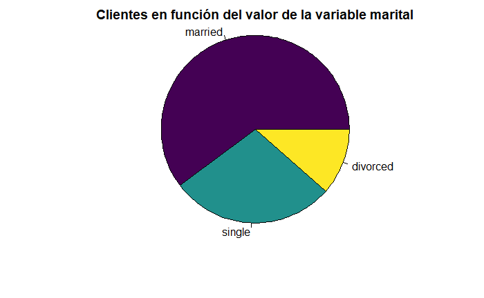

```r
# se crear una variable que cuenta para cada estado posible de la variable "marital" el número de clientes que están en este estado
# se clasifican los estados del que tiene  más clientes al que tiene menos

marital <- df_train %>%
  group_by(df_train$marital) %>%
  count() %>%
  arrange(desc(n))

# se visualiza eso en un gráfico circular (de la misma manera que para la variable "jobs")

pie(x=marital$n,
    labels = marital$`df_train$marital`,
    radius = 1,
    main = "Clientes en función del valor de la variable marital",
    col = viridis(length(marital$n)))
```

De nuevo se puede observar que los datos representan bien cada categoría de la población porque hay muchos cientes para cada categoría.

#### 2.4) Visualización de la variable “education”

Esta variable representa el nivel de educación de cada cliente. Es una variable categórica y nominal.

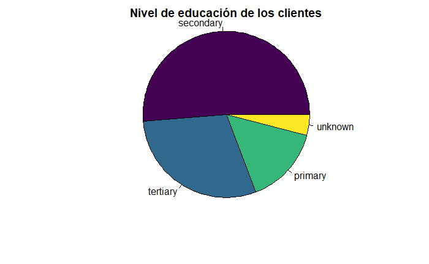

```r
nivel_educación <- df_train %>%
  group_by(df_train$education) %>%
  count() %>%
  arrange(desc(n))

pie(x=nivel_educación$n,
    labels = nivel_educación$`df_train$education`,
    radius = 1,
    main = "Nivel de educación de los clientes",
    col = viridis(length(nivel_educación$n)))
```

```r
NA
NA
```

Otra vez se puede ver que los datos representan bien cada categoría de la población.

#### 2.5) Visualización de la variable “default”

Esta variable trata de si los clientes tienen un credito impagado (si o no). Es una variable binaria que también se va a visualizar con un gráfico circular.

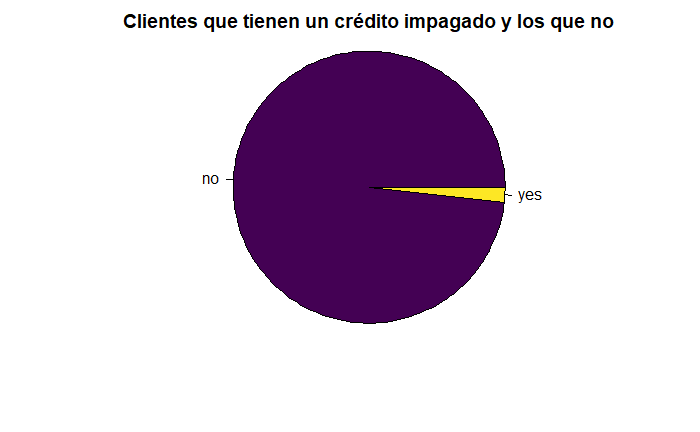

```r
crédito_impagado <- df_train %>%
  group_by(df_train$default) %>%
  count()

pie(x=crédito_impagado$n,
    labels = crédito_impagado$`df_train$default`,
    radius = 1,
    main = "Clientes que tienen un crédito impagado y los que no",
    col = viridis(length(crédito_impagado$n)))
```

Se puede ver que la mayoría de los clientes no tienen crédito impagado.

#### 2.6) Visualización de la variable “balance”

Esta variable representa el saldo anual medio (en euros) de los clientes.

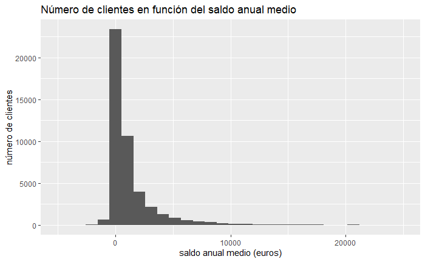

```r
 ggplot(df_train, aes(x = balance)) +
  geom_histogram(bins = 30) +
  ggtitle("Número de clientes en función del saldo anual medio") +
  labs(x="saldo anual medio (euros)", y = "número de clientes") +
  xlim(-5000, 25000)
```

Se puede ver que la mayoría de los clientes tienen un saldo anual medio cerca de 0 (menos de 5000 euros), mientras que hay una pequeña parte de los clientes que tienen un saldo anual medio más importante. Esto parece ser representativo de la población. Además, no se ve en el gráfico porque el eje “x” se para en 25 000 pero hay algunos clientes con un saldo anual medio muy grande que se pueden considerar como outliers.

#### 2.7) Visualización de la variable “housing”

Esta variable determina si el cliente tiene una propiedad (si o no).

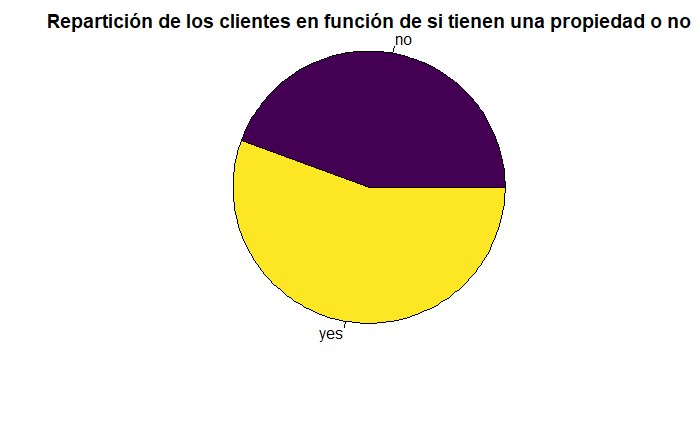

```r
housing <- df_train %>%
  group_by(df_train$housing) %>%
  count()

pie(x=housing$n,
    labels = housing$`df_train$housing`,
    radius = 1,
    main = "Repartición de los clientes en función de si tienen una propiedad o no",

    col = viridis(length(housing$n)))
```

Se puede ver que hay muchos clientes para ambas categorías.

#### 2.8) Visualización de la variable “loan”

Esta variable determina si el cliente tiene prestamos activos (si o no).

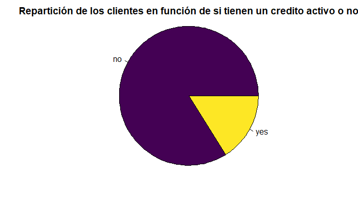

```r
loan <- df_train %>%
  group_by(df_train$loan) %>%
  count()

pie(x=loan$n,
    labels = loan$`df_train$loan`,
    radius = 1,
    main = "Repartición de los clientes en función de si tienen un credito activo o no",
    col = viridis(length(loan$n)))
```

Muchos clientes no tienen credito activo pero ambas categorías están bien representadas, así que esta variable también parece ser representativo de la población.

#### 2.9) Visualización de la variable “contact”

Esta variable determina el medio por el cual el cliente fue contactado.

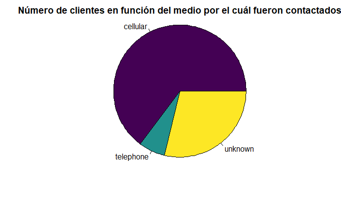

```r
contact <- df_train %>%
  group_by(df_train$contact) %>%
  count()

pie(x=contact$n,
    labels = contact$`df_train$contact`,
    radius = 1,
    main = "Número de clientes en función del medio por el cuál fueron contactados",
    col = viridis(length(contact$n)))
```

No hay mucho que interpretar de este gráfico.

#### 2.10) Visualización de la variable “day”

Esta variable representa el día del mes en el cual fue contactado el cliente. Puede ser útil tener eso porque puede tener un impacto en la decisión del cliente. Por ejemplo los clientes pueden decir mas facilmente “si” al principio del mes.

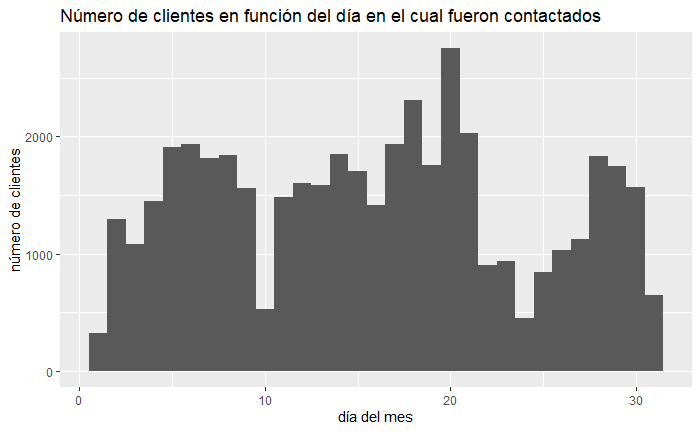

```r
ggplot(df_train, aes(x = day)) +
  geom_histogram(bins = 31) +
  ggtitle("Número de clientes en función del día en el cual fueron contactados") +
  labs(x="día del mes", y = "número de clientes")
```

#### 2.11) Visualización de la variable “duration”

Esta variable representa la duración de la llamada (en segundos).

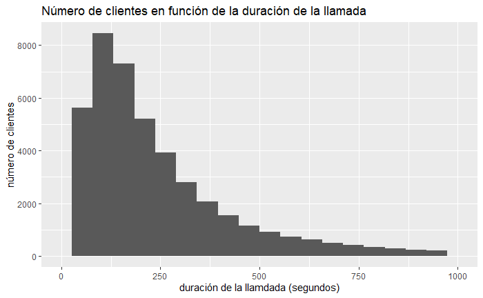

```r
ggplot(df_train, aes(x = duration)) +
  geom_histogram(bins = 20) +
  ggtitle("Número de clientes en función de la duración de la llamada") +
  labs(x="duración de la llamdada (segundos)", y = "número de clientes") +
  xlim(0,1000)
```

Sólo se puede observar que la mayoría de las llamadas duran menos de 10 minutos y muchas duran 2-3 minutos.

Las visualización de las siguientes variables es de poco interés, así que ahora solo se va a visualizar la clase final.

#### 2.12) Visualización de la clase final

Esta variable dice si el cliente ha suscrito a un un term deposit (si o no). La visualización de esta variable permite ver si no hay desequilibrio entre las 2 clases que queremos predecir.

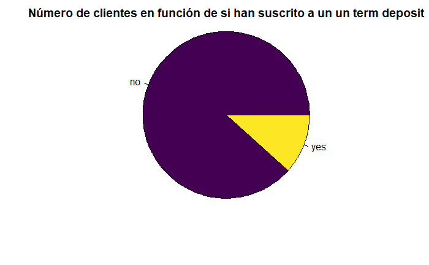

```r
clase_final <- df_train %>%
  group_by(df_train$y) %>%
  count()

pie(x=clase_final$n,
    labels = clase_final$`df_train$y`,
    radius = 1,
    main = "Número de clientes en función de si han suscrito a un un term deposit",
    col = viridis(length(clase_final$n)))
```

### 3) Aprendizaje supervisado : entrenamiento de un algoritmo de regresión

Ahora se van a aplicar técnicas de regresión aprendidas en clase para hacer predicciones. Más precisamente, lo que se va a hacer es intentar predecir el saldo anual medio de un cliente a partir de las otras variables.

#### 3.1) Preprocesamiento

Se ha visto en la parte de visualización que hay outliers en los valores del saldo anual medio. Por lo tanto, se van a eliminar los clientes con un saldo anual medio superior a 15 000, ya que pueden impedir que el modelo se ajuste a los datos correctamente.

```r
datos_sin_outliers <- df_train %>%
  filter(balance < 15000)
```

#### 3.2) Regresion lineal simple

Primero se verificará si es posible predecir el saldo anual medio con solamente una variable que es la variable edad. Se puede suponer que es dificil hacer eso pero al menos se puede ver si hay una tendencia que hace que las personas mayores tienen un saldo anual más alto, por ejemplo.

Para empezar se pone en un gráfico el saldo anual en función de la edad.

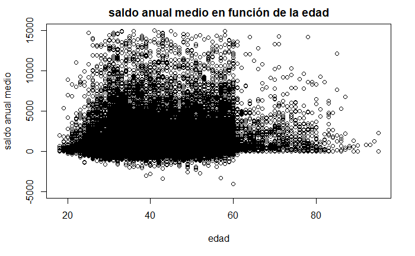

```r
plot(x = datos_sin_outliers$age,
     y = datos_sin_outliers$balance,
     main = "saldo anual medio en función de la edad",
     xlab="edad",
     ylab="saldo anual medio",
     ylim=c(-5000, 15000))
```

No se pueden ver muchas cosas con eso. Ahora se va a calcular y dibujar una recta de regresión en el gráfico.

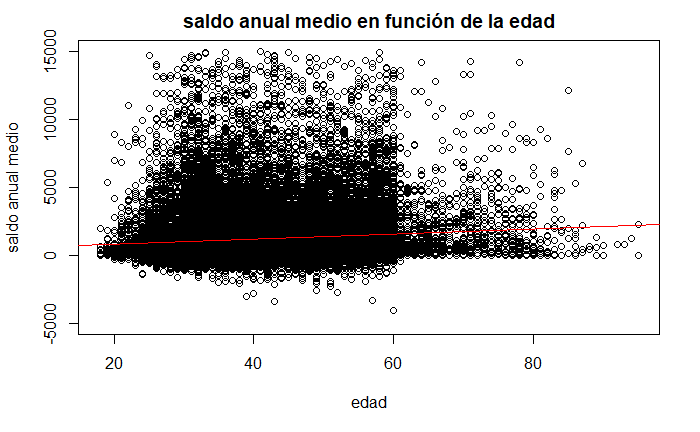

```r
# Calculamos la regresión
lineal_simple <- lm(balance ~ age, data = datos_sin_outliers)

# Ponemos otra vez el gráfico pero con la recta de regresión
plot(x = datos_sin_outliers$age,
     y = datos_sin_outliers$balance,
     main = "saldo anual medio en función de la edad",
     xlab="edad",
     ylab="saldo anual medio",
     ylim=c(-5000, 15000))
abline(lineal_simple$coefficients, col = "red")
```

Hay una pequeña pendiente que parece decir que las personas mayores tienen un saldo anual medio un poco más alto. Pero para evaluar la calidad de la regresión se va a calcular una métrica de evaluación : el R_square que es un valor entre 0 (malo) y 1 (bueno).

```r
# Para cada cliente se intenta predecir el saldo anual medio a partir de la edad
saldo_anual_prediccion <- predict(lineal_simple)

# Se calcula la diferencia con el valor real
diferencia <- datos_sin_outliers$balance - saldo_anual_prediccion

# Se calcula el valor del R_square
#   -> se calcula la suma de los residuos (= varianza del saldo anual medio que no se puede explicar con la regresión)
#   -> se calcula la suma total de la varianza del saldo anual medio
#   -> se utiliza la fórmula que permite calcular el R_square (= porcentaje de la varianza total que se puede explicar con la regresión)
suma_residuos <- sum(diferencia^2)
suma_total <- sum((datos_sin_outliers$balance - mean(datos_sin_outliers$balance)) ^ 2)
r_square <- 1 - (suma_residuos / suma_total)
print(paste("R_square = ", r_square))
```

```
[1] "R_square =  0.00981882902467823"
```

Se tiene un R_square muy cerca de 0, lo que significa que este modelo de regresión es muy malo y que sólo la edad no es suficiente para predecir el saldo anual medio de un cliente (lo que de hecho parece bastante lógico).

#### 3.3) Regresión multivariable

Ahora se intentará predecir el saldo anual de un cliente pero mirando a todas las otras variables y no sólo la edad.

```r
# Se construye el modelo de regresión
multivariable <- lm(balance ~ ., data = datos_sin_outliers)
# Se observan todas las métricas
summary(multivariable)
```

```
Call:
lm(formula = balance ~ ., data = datos_sin_outliers)

Residuals:
    Min      1Q  Median      3Q     Max
-7071.5 -1015.3  -559.1   236.3 14009.8

Coefficients:
                     Estimate Std. Error t value Pr(>|t|)
(Intercept)          428.7097   102.3175   4.190 2.79e-05 ***
age                   18.2373     1.1320  16.111  < 2e-16 ***
jobblue-collar        37.0431    35.3432   1.048 0.294599
jobentrepreneur      -65.5710    58.9490  -1.112 0.266000
jobhousemaid           2.5454    63.8820   0.040 0.968216
jobmanagement        169.6274    39.2658   4.320 1.56e-05 ***
jobretired            35.8080    55.0365   0.651 0.515293
jobself-employed     140.7057    57.5598   2.445 0.014509 *
jobservices           -6.1546    40.7038  -0.151 0.879815
jobstudent           208.7280    72.1783   2.892 0.003832 **
jobtechnician         84.6568    35.6825   2.373 0.017672 *
jobunemployed        151.6572    61.2278   2.477 0.013255 *
jobunknown            86.9823   121.1230   0.718 0.472680
maritalmarried       260.5444    29.8514   8.728  < 2e-16 ***
maritalsingle        294.8811    34.5636   8.532  < 2e-16 ***
educationsecondary    17.5729    29.6106   0.593 0.552872
educationtertiary    232.9474    37.0914   6.280 3.41e-10 ***
educationunknown     108.0024    52.7927   2.046 0.040784 *
defaultyes         -1162.5858    69.1749 -16.806  < 2e-16 ***
housingyes           -76.1787    22.3591  -3.407 0.000657 ***
loanyes             -420.8637    25.6950 -16.379  < 2e-16 ***
contacttelephone     151.1357    39.2328   3.852 0.000117 ***
contactunknown       -76.8449    31.7130  -2.423 0.015391 *
day                    5.7088     1.2797   4.461 8.18e-06 ***
monthaug            -265.6662    46.9729  -5.656 1.56e-08 ***
monthdec             209.3960   139.4525   1.502 0.133218
monthfeb            -234.7174    55.0390  -4.265 2.01e-05 ***
monthjan            -578.1268    65.2823  -8.856  < 2e-16 ***
monthjul            -425.0212    44.8846  -9.469  < 2e-16 ***
monthjun             146.9358    53.3201   2.756 0.005859 **
monthmar             274.0413    97.7600   2.803 0.005062 **
monthmay            -252.1224    43.5739  -5.786 7.25e-09 ***
monthnov             671.7001    48.5609  13.832  < 2e-16 ***
monthoct             192.3620    82.2403   2.339 0.019339 *
monthsep              64.2153    90.7876   0.707 0.479375
duration               0.1723     0.0394   4.373 1.23e-05 ***
campaign              -4.4405     3.1311  -1.418 0.156136
pdays                 -0.9271     0.1984  -4.673 2.97e-06 ***
previous               3.3889     4.7278   0.717 0.473500
poutcomeother        -26.7206    53.7959  -0.497 0.619401
poutcomesuccess       39.2441    62.0536   0.632 0.527114
poutcomeunknown     -270.5188    59.3690  -4.557 5.21e-06 ***
yyes                 174.4881    34.2097   5.101 3.40e-07 ***
---
Signif. codes:  0 ‘***’ 0.001 ‘**’ 0.01 ‘*’ 0.05 ‘.’ 0.1 ‘ ’ 1

Residual standard error: 1944 on 44817 degrees of freedom
Multiple R-squared:  0.06719,   Adjusted R-squared:  0.06632
F-statistic: 76.86 on 42 and 44817 DF,  p-value: < 2.2e-16
```

El valor de R_squared es 0.06, lo que significa que solo el 6% de la variación del saldo anual medio se puede explicar con las variables de entrada, lo que significa que el modelo no se ajusta bien a los datos. Puede ser que las otras variables no tienen mucha influencia en el saldo anual medio.

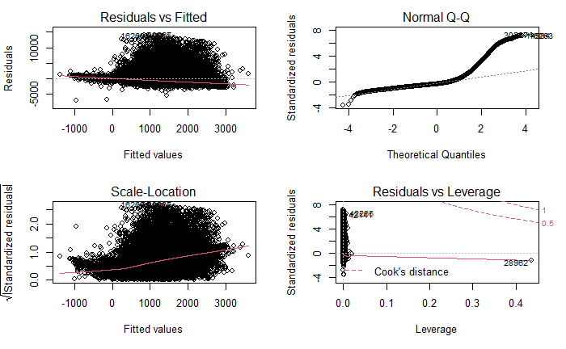

```r
# Algunos gráficos para visualizar un poco los resultados de la regresión
par(mfrow=c(2,2))
plot(multivariable)
```

### 4) Aprendizaje supervisado : entrenamiento de clasificadores

Ahora, se van a entrenar varios clasificadores para predecir si el cliente es interesante o no. Se va a probar cada clasificador con el conjunto de test y despues se va a comparar los resultados de cada uno para elegir lo mejor.

#### 4.1) Árbol de decisión

rpart (Rercursive Partitioning And Regression Trees) es una librería que permite entrenar árboles de decisión para hacer predicciones. Se va a utilizar para construir un árbol de decisión que permite predecir el valor de la variable “y” que representa la respuesta del cliente (si o no) para suscribir a un term deposit.

```r
# descomentar las siguientes líneas si ya no están instalados los packages "rattle" y "rpart.plot"
# install.packages("rattle")
# install.packages(rpart.plot)

# se construye el árbol
library(rpart)

mytree <- rpart(
  y ~ .,
  data = df_train,
  method = "class"
)

# se imprime el árbol construido
mytree
```

```
n= 45211

node), split, n, loss, yval, (yprob)
      * denotes terminal node

 1) root 45211 5289 no (0.88301520 0.11698480)
   2) duration< 521.5 40238 3106 no (0.92280928 0.07719072)
     4) poutcome=failure,other,unknown 38941 2301 no (0.94091061 0.05908939) *
     5) poutcome=success 1297  492 yes (0.37933693 0.62066307)
      10) duration< 162.5 360  113 no (0.68611111 0.31388889) *
      11) duration>=162.5 937  245 yes (0.26147279 0.73852721) *
   3) duration>=521.5 4973 2183 no (0.56102956 0.43897044)
     6) duration< 827.5 3191 1147 no (0.64055155 0.35944845)
      12) poutcome=failure,other,unknown 3047 1030 no (0.66196259 0.33803741) *
      13) poutcome=success 144   27 yes (0.18750000 0.81250000) *
     7) duration>=827.5 1782  746 yes (0.41863075 0.58136925) *
```

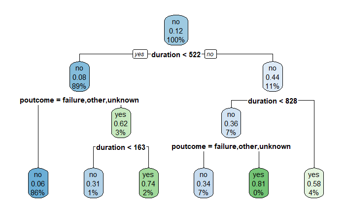

```r
# Se traza el árbol de decisión
library(rpart.plot)
rpart.plot(mytree)
```

Se puede ver que la duración de la llamada y el éxito (o no) de la campaña de marketing anterior tienen mucho impacto en el resultado.

```r
# Se hacen predicciones sobre datos de prueba
preds <- predict(mytree, newdata = df_test, type = "class")
```

```r
#se comprueba la precisión del árbol de decisión en los datos de prueba
precision = mean(preds == df_test$y)
print(paste("El árbol clasifica bien ",precision*100,"% de los datos."))
```

```
[1] "El árbol clasifica bien  90.0022119000221 % de los datos."
```

Este resultado parece bueno, pero no significa que el clasificador es bueno : por ejemplo si se tiene 90% de los clientes que dicen “no”, un clasificador estúpido que clasifica todos los clientes como clientes que van a decir “no” tiene 90% de precisión, por eso hay que mirar a la matriz de confusión para verificar que el algoritmo funciona bien.

```r
# Matriz de confusión del árbol de decisión sobre los datos de prueba.
matriz_confusion = table(df_test$y, preds)
matriz_confusion
```

```
     preds
        no  yes
  no  3896  104
  yes  348  173
```

#### 4.2) Clasificador Knn

Ahora se va a utilizar el algoritmo Knn (K-Nearest-Neighbors), visto en clase para hacer la clasificación.

Primero hay que que convertir las variables categóricas en variables numéricas porque con el algoritmo KNN hace falta calcular la distancia entre los datos y para hacer eso se necesitan variables numéricas.

```r
# convertir variables categóricas en numéricas para los datos de entrenamiento
# install.packages("fastDummies")
library(fastDummies)
df_traind <- df_train
df_traind$default <- ifelse(df_traind$default == "yes",1,0)
df_traind$housing <- ifelse(df_traind$housing == "yes",1,0)
df_traind$loan <- ifelse(df_traind$loan == "yes",1,0)
df_traind$month <- recode(df_traind$month, "jan" = 1, "feb" = 2, "mar" = 3, "apr" = 4,  "may" = 5, "jun" = 6, "jul" = 7, "aug" = 8, "sep" = 9, "oct" = 10, "nov" = 11, "dec" = 12)
df_traind <- dummy_cols(df_traind,remove_selected_columns = T, select_columns = c("job", "marital", "education", "contact", "poutcome"))
```

```r
#convertir variables categóricas en numéricas para datos de prueba
df_testd <- df_test
df_testd$default <- ifelse(df_testd$default == "yes",1,0)
df_testd$housing <- ifelse(df_testd$housing == "yes",1,0)
df_testd$loan <- ifelse(df_testd$loan == "yes",1,0)

df_testd$month <- recode(df_testd$month, "jan" = 1, "feb" = 2, "mar" = 3, "apr" = 4,  "may" = 5, "jun" = 6, "jul" = 7, "aug" = 8, "sep" = 9, "oct" = 10, "nov" = 11, "dec" = 12)

df_testd <- dummy_cols(df_testd,remove_selected_columns = T, select_columns = c("job", "marital", "education", "contact", "poutcome"))
```

Ahora se va a aplicar el algoritmo, pero para eso hace falta elegir con qué valor de “k” (= número de vecinos más cercanos) se va a aplicar el algoritmo.

No se puede saber de antemano cuál es el mejor valor para k, por lo tanto se va a aplicar el algoritmo con varios valores de k y elegir el valor que da los mejores resultados. (Como se entrenaron varios clasificadores es normal si la ejecución del siguiente código lleva algunos minutos)

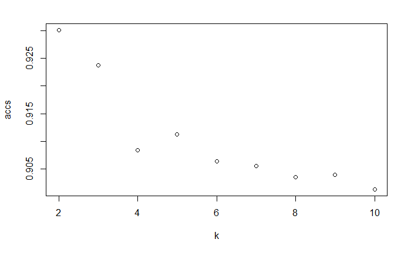

```r
# # descomentar la siguiente línea si ya no está instalado el package "class"
# install.packages("class")
library(class)

# se va a aplicar el algoritmo con valores k de 2 a 10
range <- 2:10
accs <- rep(0, length(range))

for (k in range) {
  # se entrena el clasificador
  clasificador <- knn(train = df_traind[,-c(12)],
                      test = df_testd[, -c(12)],
                      cl = df_traind$y, k = k)

  # se calcula la matriz de confusión
  matriz_confusion <- table(df_testd$y, clasificador)

  # se calcula la precisión
  accs[k-1] <- sum(diag(matriz_confusion)) / sum(matriz_confusion)
}

# Se visualiza la precisión para cada valor de k
plot(range, accs, xlab = "k")
```

Se ve en el gráfico que hay buenos resultados (precisión superior al 90%) con todos los valores de k, y hay una precisión de más de 92% con k=2 y k=3. Se va a calcular con más detalle la precisión que se obtiene con el mejor k.

```r
k_best = which.max(accs) + 1
precision_best = accs[which.max(accs)]
print(paste("El mejor número de vecinos es k =", k_best,"y tenemos una precisión de ",precision_best*100,"%." ))
```

```
[1] "El mejor número de vecinos es k = 2 y tenemos una precisión de  93.010395930104 %."
```

Dado que el rendimiento del clasificador KNN es más alto que el del árbol de decisión, el clasificador knn se generaliza y se ajusta bien a los datos y funciona mejor que el árbol de decisión y se puede utilizar para predicciones futuras.

### 5) Aplicación de algoritmos de clustering

Para terminar, se van a aplicar varios algoritmos de clustering para ver si el conjunto de clientes se puede dividir en varios subconjuntos con clientes que se parecen, y comparar los resultados de estos algoritmos de clustering.

#### 5.1) Kmeans Clustering

Primero se va a utilizar el algoritmo KMeans visto en clase. No se puede saber de antemano cuál es el número óptimo de clusters, así que se va a intentar hacer el clustering con varios números de clusters (se va a hacerlo para k = 2 a 7) y elegir lo mejor.

Para hacer eso, se va a calcular para cada valor de k el WSS (Within cluster Sum of Square). WWS es una métrica que calcula si los datos que pertenecen a un mismo cluster están cerca, por lo tanto el objetivo es tener un valor lo más pequeño posible para WWS. Cuando se aumenta el número de clusters, el WWS siempre baja, pero no queremos un número de clusters igual que el número de datos, por lo tanto lo que se hace para elegir el número de clusters óptimo es visualizar en un gráfico el valor de WWS para varios valores de k, y elegir el número de cluster que corresponde a un “codo” en el gráfico. En efecto este valor coresponde al nivel en lo que aumentar el número de clusters no aporta mucho.

```r
# Se initializa el WSS que se va a calcular
wss<-0


# Se aplica el algorimto para k de 2 a 7
for(k in 2:7){
  set.seed(1)
  km <- kmeans(df_traind[,-c(12)], centers = k, nstart = 25)
  wss[k-1] <- km$tot.withinss
}
```

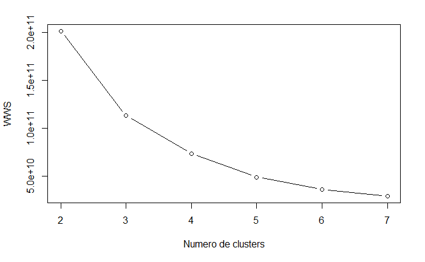

```r
# Se construye la ventana en la que se va a visualizar los resultados
par(mfrow = c(1,1))

# Se visualiza los valores de WWS para los distintos valores de k
plot(2:7, wss, type = "b",
     xlab = "Numero de clusters",
     ylab = "WWS")
```

Se puede ver un pequeño codo para k=3, aunque no es muy pronunciado. Por lo tanto el mejor número de cluster es 3.

#### 5.2) Cluseting jerárquico

Se va a aplicar un clustering jerárquico con un número de cluster k = 3 y se va a visualizar el resultado con un dendrograma.

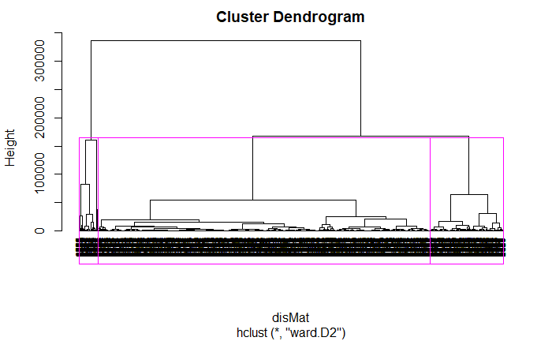

```r
# Se dice que se va a utilizar la distancia euclidiena para calcular la distancia entre los datos
disMat <- dist(Datos, method = "euclidean")
# Se utilice el algoritmo y se indica que se calcula la distancia entre los clusters con Ward's method

modelo <- hclust(disMat, method = "ward.D2")
plot(modelo, cex = 0.6, hang = -1)
rect.hclust(modelo, k = 3, border = "magenta")
```